# Tugas Praktikum 4 MPDW

```r
library(ggplot2)
library(tsibble)
library(tseries)
library(ggpubr)
library (TSA)
set.seed(2026)

theta1 <- 0.4
theta2 <- 0.6
n      <- 300

denom  <- 1 + theta1^2 + theta2^2
rho1_teori <- theta1 * (1 + theta2) / denom
rho2_teori <- theta2 / denom
rho3_teori <- 0

c(var_teori = denom, rho1 = rho1_teori, rho2 = rho2_teori, rho3 = rho3_teori)
```

```
## var_teori      rho1      rho2      rho3
## 1.5200000 0.4210526 0.3947368 0.0000000
```

# Proses MA (2)

## Membangkitkan Data

### Manual

```r
n <- 300
e <- rnorm(n + 2)          # 2 nilai awal sebagai burn-in

Y_manual <- numeric(n)
for (t in 3:(n + 2)) {
  Y_manual[t - 2] <- e[t] + theta1 * e[t - 1] + theta2 * e[t - 2]
}
Y_manual <- ts(Y_manual)

mean(Y_manual)
```

```
## [1] 0.08317082
```

```r
var(Y_manual)
```

```
## [1] 1.338952
```

### Arima.sim

```r
Y_sim <- arima.sim(n = 300, model = list(ma = c(theta1, theta2)))

mean(Y_sim)
```

```
## [1] 0.1535241
```

```r
var(Y_sim)
```

```
## [1] 1.692523
```

## Plot Time Series

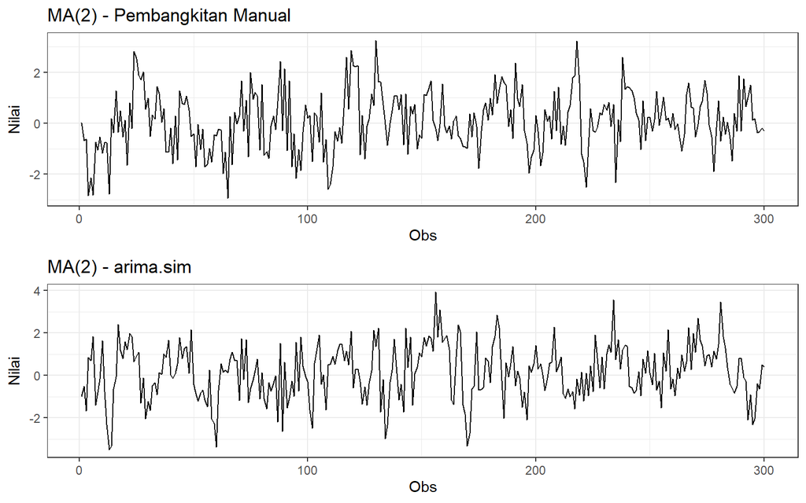

```r
plot_manual <- Y_manual |> as_tsibble() |>
  ggplot(aes(x = index, y = value)) + geom_line() + theme_bw() +
  xlab("Obs") + ylab("Nilai") + ggtitle("MA(2) - Pembangkitan Manual")

plot_sim <- Y_sim |> as_tsibble() |>
  ggplot(aes(x = index, y = value)) + geom_line() + theme_bw() +
  xlab("Obs") + ylab("Nilai") + ggtitle("MA(2) - arima.sim")

ggpubr::ggarrange(plot_manual, plot_sim, nrow = 2)
```

Kedua plot deret waktu menunjukkan data yang berfluktuasi di sekitar nilai tengah nol dengan lebar pita yang relatif konstan sepanjang waktu — indikasi awal bahwa data **stasioner dalam rataan dan ragam**, sesuai sifat proses MA yang memang selalu stasioner.

## Plot ACF, PACF, dan EACF

### Plot ACF

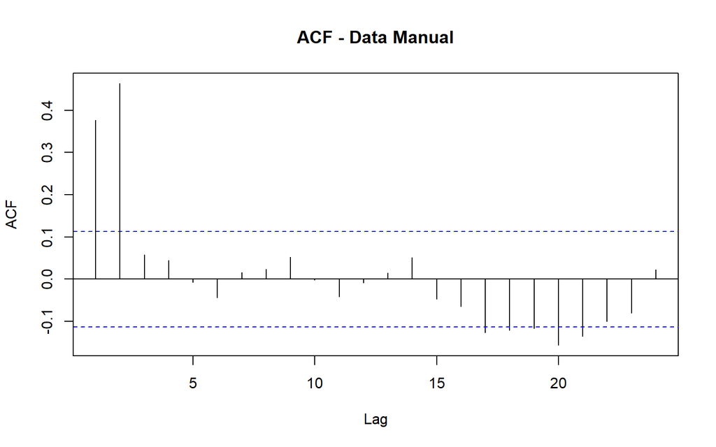

```r
acf(Y_manual, main = "ACF - Data Manual")
```

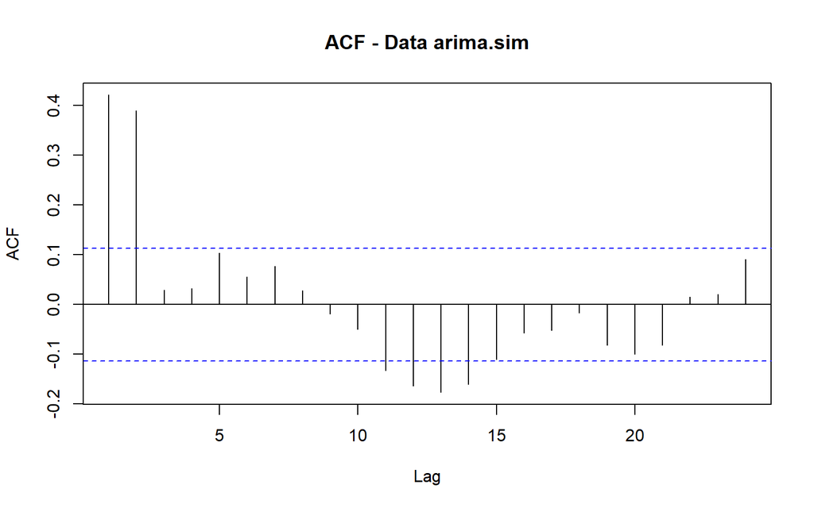

```r
acf(Y_sim, main = "ACF - Data arima.sim")
```

Plot ACF pada kedua data menunjukkan nilai signifikan pada lag 1 dan lag 2, kemudian **terputus (*cuts off*) setelah lag 2** — pola ini sesuai dengan sifat teoritis MA(2) yang autokorelasinya nol untuk $k\geq3$.

### Plot PACF

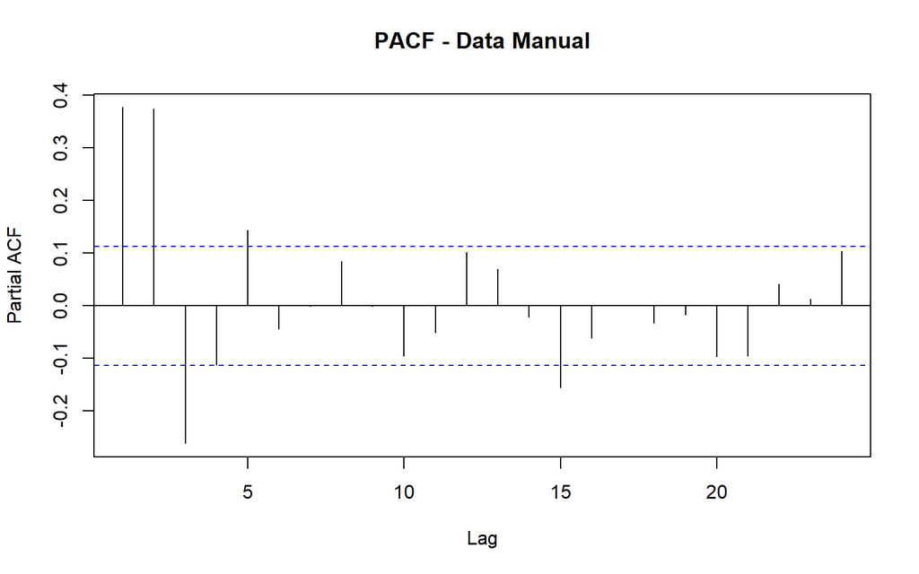

```r
pacf(Y_manual, main = "PACF - Data Manual")
```

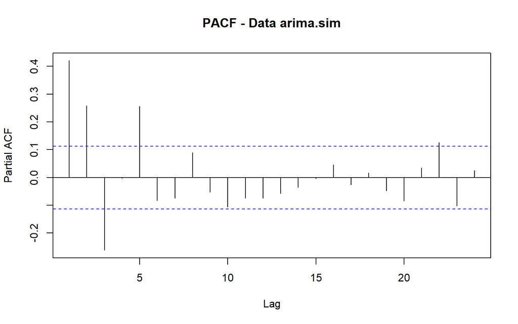

```r
pacf(Y_sim, main = "PACF - Data arima.sim")
```

Berbeda dengan ACF, plot PACF menurun secara berangsur (*tails off*) dan tidak terputus tajam pada lag tertentu. Hal ini konsisten dengan teori bahwa representasi AR($\infty$) dari proses MA akan memiliki PACF yang meluruh secara bertahap, bukan terputus.

### Plot EACF

```r
TSA::eacf(Y_manual)
```

```
## AR/MA
##   0 1 2 3 4 5 6 7 8 9 10 11 12 13
## 0 x x o o o o o o o o o  o  o  o
## 1 x x x o o o o o o o o  o  o  o
## 2 x x x x o o o o o o o  o  o  o
## 3 x x x x o o o o o o o  o  o  o
## 4 x x o x o o o o o o o  o  o  o
## 5 x x o x x o x o o o o  o  o  o
## 6 o o x x x o o o o o o  o  o  o
## 7 o x o o o o x o o o o  o  o  o
```

```r
TSA::eacf(Y_sim)
```

```
## AR/MA
##   0 1 2 3 4 5 6 7 8 9 10 11 12 13
## 0 x x o o o o o o o o x  x  x  x
## 1 x x x o o o o o o o o  o  o  o
## 2 x x x o o o o o o o o  o  o  o
## 3 o x x x x o o o o o o  o  o  o
## 4 o x x x x x o o o o o  o  o  o
## 5 x x x x x x o o o o o  o  o  o
## 6 x x o x o x o o o o o  o  o  o
## 7 x x o o o x o o o o o  o  o  o
```

Pada tabel EACF, pola yang diharapkan adalah munculnya “segitiga” nilai tidak signifikan (simbol `o`) dengan titik sudut (*vertex*) di baris AR = 0 dan kolom MA = 2. Pola ini menjadi penciri identifikasi bahwa proses merupakan **MA murni berorde 2**, tanpa komponen AR.

### Identifikasi Stasioneritas

Ketiga plot (time series, ACF, PACF) secara konsisten menunjukkan data **stasioner dalam rataan dan ragam**: plot time series berfluktuasi di sekitar nilai tengah konstan, ACF cuts off setelah lag 2, dan tidak ada indikasi tren atau perubahan lebar pita yang sistematis.

Sebagai konfirmasi formal, dilakukan uji ADF:

```r
tseries::adf.test(Y_manual)
```

```
##
##  Augmented Dickey-Fuller Test
##
## data:  Y_manual
## Dickey-Fuller = -6.035, Lag order = 6, p-value = 0.01
## alternative hypothesis: stationary
```

```r
tseries::adf.test(Y_sim)
```

```
##
##  Augmented Dickey-Fuller Test
##
## data:  Y_sim
## Dickey-Fuller = -5.7503, Lag order = 6, p-value = 0.01
## alternative hypothesis: stationary
```

$H_0$: Data tidak stasioner dalam rataan $H_1$: Data stasioner dalam rataan

## Scatterplot $Y_t$ dengan Lag

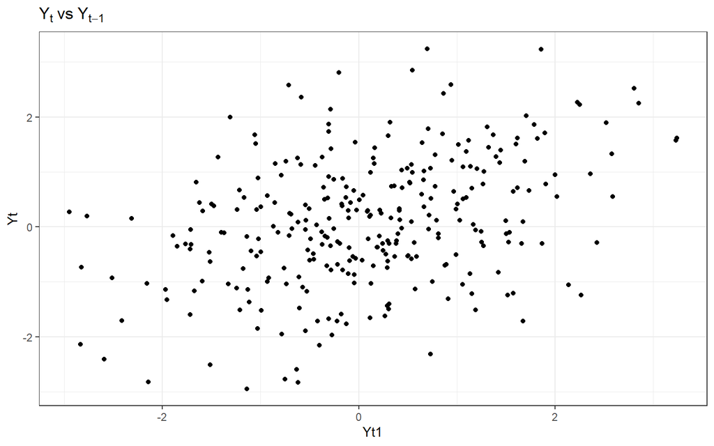

```r
Yv  <- as.numeric(Y_manual)
Nn  <- length(Yv)

df_lag <- data.frame(
  Yt  = Yv[4:Nn],
  Yt1 = Yv[3:(Nn - 1)],
  Yt2 = Yv[2:(Nn - 2)],
  Yt3 = Yv[1:(Nn - 3)]
)

ggplot(df_lag, aes(x = Yt1, y = Yt)) +
  geom_point() + theme_bw() + ggtitle(expression(Y[t]~"vs"~Y[t-1]))
```

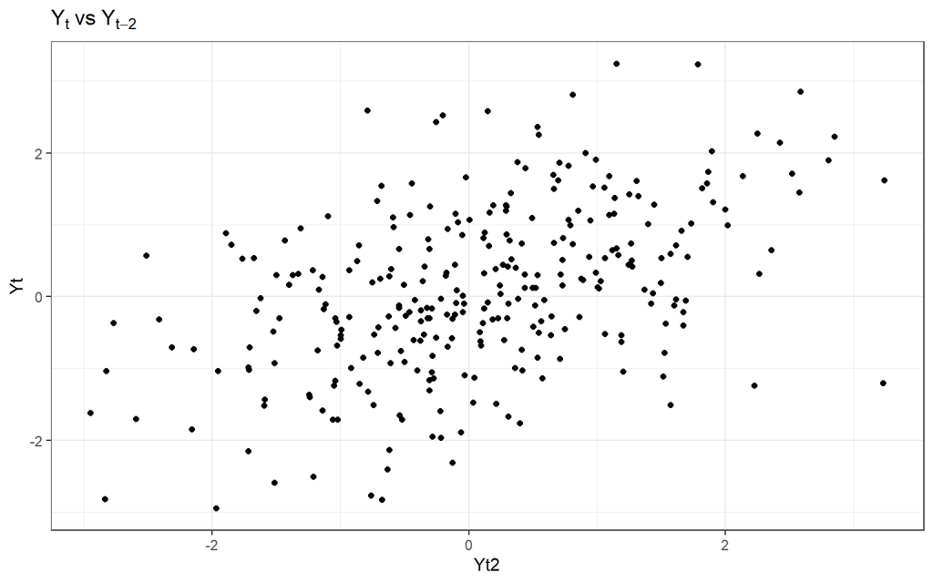

```r
ggplot(df_lag, aes(x = Yt2, y = Yt)) +
  geom_point() + theme_bw() + ggtitle(expression(Y[t]~"vs"~Y[t-2]))
```

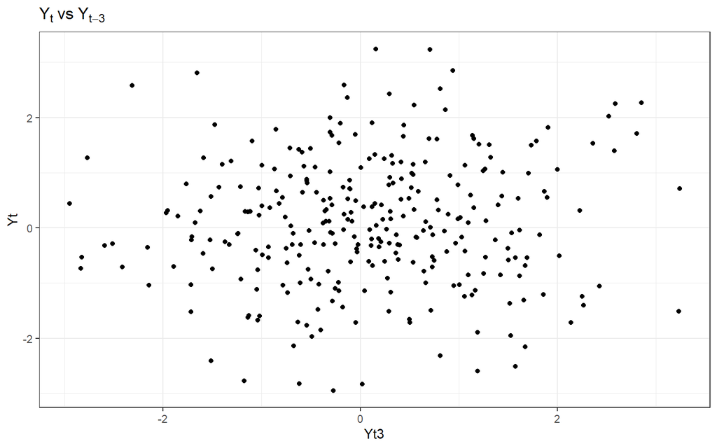

```r
ggplot(df_lag, aes(x = Yt3, y = Yt)) +
  geom_point() + theme_bw() + ggtitle(expression(Y[t]~"vs"~Y[t-3]))
```

Scatterplot $Y_t$ vs $Y_{t-1}$ dan $Y_t$ vs $Y_{t-2}$ menunjukkan pola sebaran titik yang cenderung membentuk **tren linear positif ringan**, sedangkan scatterplot $Y_t$ vs $Y_{t-3}$ menunjukkan sebaran titik yang **acak tanpa pola** — konsisten dengan ACF yang terputus setelah lag 2.

## Autokorelasi: Empiris vs Teoritis

```r
ac_manual <- acf(Y_manual, plot = FALSE)$acf[2:4]
ac_sim    <- acf(Y_sim, plot = FALSE)$acf[2:4]

hasil <- data.frame(
  Lag              = 1:3,
  Teoritis         = c(rho1_teori, rho2_teori, rho3_teori),
  Empiris_Manual   = ac_manual,
  Empiris_arimaSim = ac_sim
)
round(hasil, 3)
```

```
##   Lag Teoritis Empiris_Manual Empiris_arimaSim
## 1   1    0.421          0.463            0.389
## 2   2    0.395          0.057            0.029
## 3   3    0.000          0.045            0.032
```

# Proses AR (2)

```r
phi1 <- 0.5
phi2 <- 0.2

c(syarat1 = phi1 + phi2 < 1,
  syarat2 = phi2 - phi1 < 1,
  syarat3 = abs(phi2) < 1)
```

```
## syarat1 syarat2 syarat3
##    TRUE    TRUE    TRUE
```

```r
rho <- numeric(6)
rho[1] <- phi1 / (1 - phi2)                 # rho1
for (k in 2:6) {
  rho[k] <- phi1 * rho[k - 1] + phi2 * ifelse(k - 2 == 0, 1, rho[k - 2])
}
names(rho) <- paste0("rho", 1:6)
round(rho, 4)
```

```
##   rho1   rho2   rho3   rho4   rho5   rho6
## 0.6250 0.5125 0.3812 0.2931 0.2228 0.1700
```

## Membangkitkan Data

### Manual

```r
n <- 300
burn <- 50
e <- rnorm(n + burn)

Y <- numeric(n + burn)
for (t in 3:(n + burn)) {
  Y[t] <- phi1 * Y[t - 1] + phi2 * Y[t - 2] + e[t]
}
Y_manual <- ts(Y[(burn + 1):(n + burn)])   # buang burn-in

mean(Y_manual)
```

```
## [1] -0.100311
```

```r
var(Y_manual)
```

```
## [1] 1.502916
```

### Arima.sim

```r
Y_sim <- arima.sim(n = 300, model = list(ar = c(phi1, phi2)))

mean(Y_sim)
```

```
## [1] 0.1145179
```

```r
var(Y_sim)
```

```
## [1] 1.813903
```

## Plot Time Series

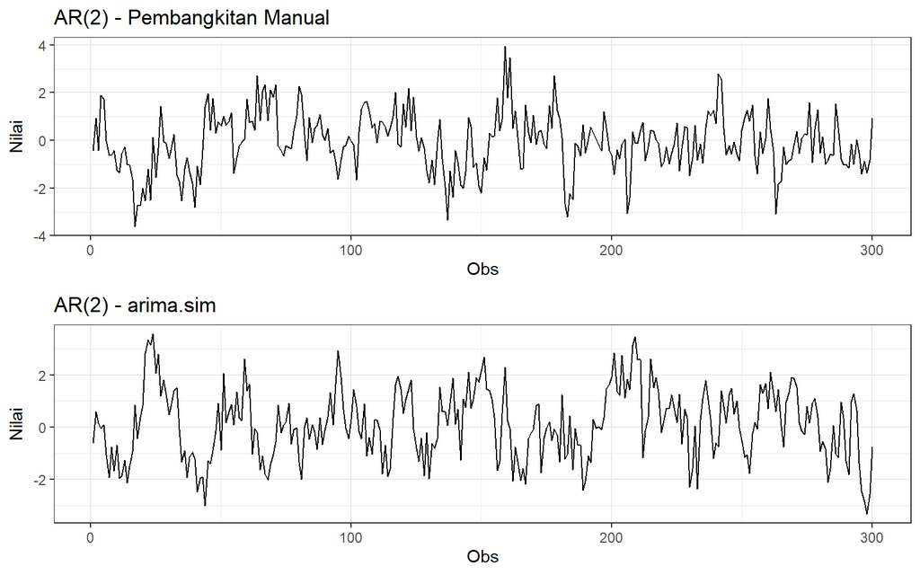

```r
plot_manual <- Y_manual |> as_tsibble() |>
  ggplot(aes(x = index, y = value)) + geom_line() + theme_bw() +
  xlab("Obs") + ylab("Nilai") + ggtitle("AR(2) - Pembangkitan Manual")

plot_sim <- Y_sim |> as_tsibble() |>
  ggplot(aes(x = index, y = value)) + geom_line() + theme_bw() +
  xlab("Obs") + ylab("Nilai") + ggtitle("AR(2) - arima.sim")

ggpubr::ggarrange(plot_manual, plot_sim, nrow = 2)
```

Kedua plot menunjukkan data berfluktuasi di sekitar nilai tengah yang relatif konstan dengan lebar pita stabil — indikasi awal **stasioner dalam rataan dan ragam**.

## Plot ACF, PACF, dan EACF

### Plot ACF

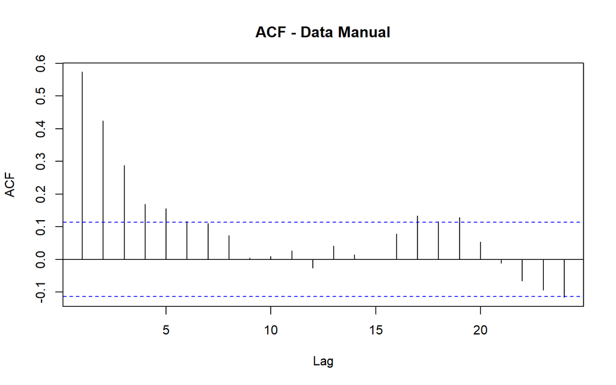

```r
acf(Y_manual, main = "ACF - Data Manual")
```

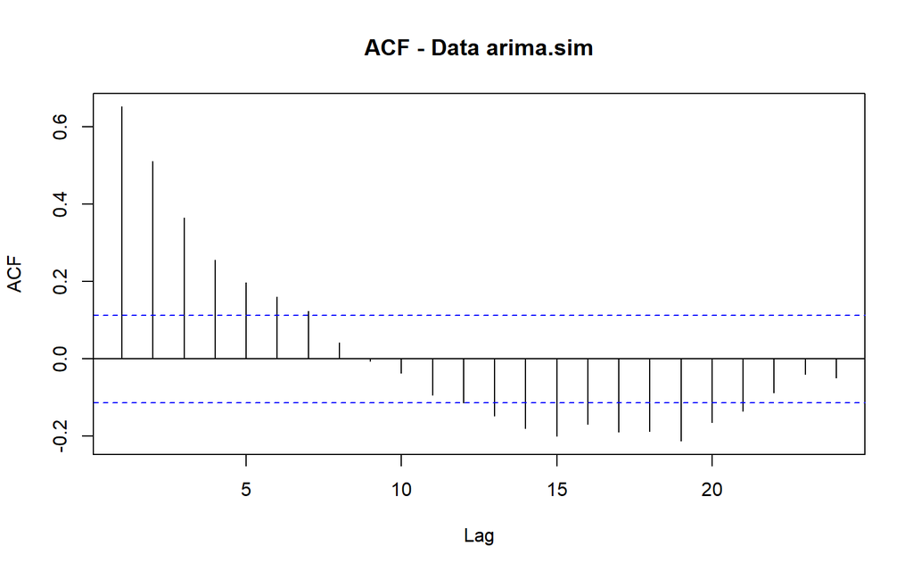

```r
acf(Y_sim, main = "ACF - Data arima.sim")
```

Plot ACF menurun secara berangsur/eksponensial (*tails off*) tanpa titik potong tegas — pola khas proses **AR**, konsisten dengan perhitungan teoritis Yule-Walker di atas.

### Plot PACF

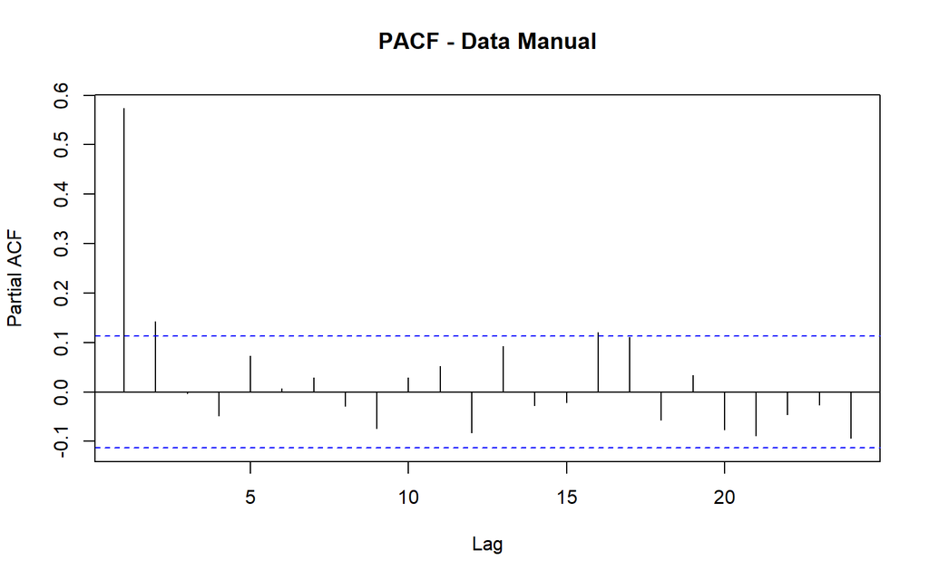

```r
pacf(Y_manual, main = "PACF - Data Manual")
```

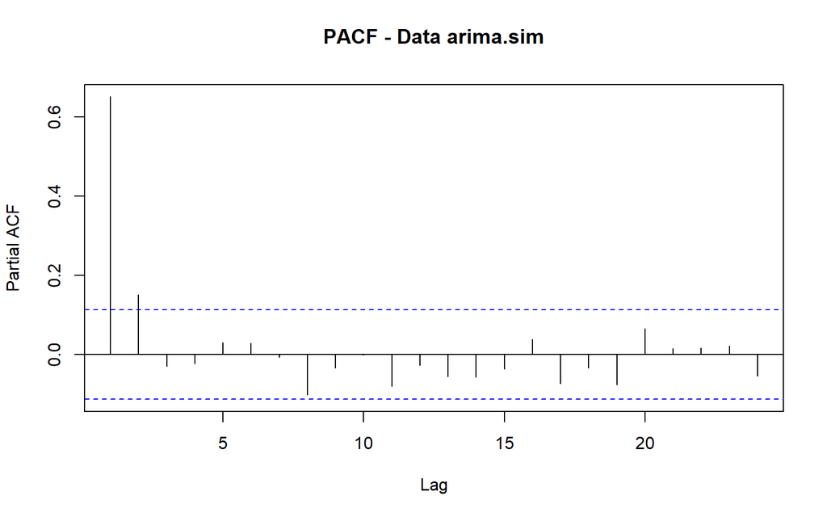

```r
pacf(Y_sim, main = "PACF - Data arima.sim")
```

Berbeda dengan ACF, PACF menunjukkan nilai signifikan hanya pada lag 1 dan lag 2, kemudian **terputus (*cuts off*) setelah lag 2** — pola ini adalah ciri identifikasi orde AR, yaitu $p=2$.

### Plot EACF

```r
TSA::eacf(Y_manual)
```

```
## AR/MA
##   0 1 2 3 4 5 6 7 8 9 10 11 12 13
## 0 x x x x x o o o o o o  o  o  o
## 1 x o o x o o o o o o o  o  o  o
## 2 o o o o o o o o o o o  o  o  o
## 3 o o o o o o o o o o o  o  o  o
## 4 x x x x o o o o o o o  o  o  o
## 5 o x x x o o o o o o o  o  o  o
## 6 x x x x x o o o o o o  o  o  o
## 7 x x o x o o x o o o o  o  o  o
```

```r
TSA::eacf(Y_sim)
```

```
## AR/MA
##   0 1 2 3 4 5 6 7 8 9 10 11 12 13
## 0 x x x x x x x o o o o  o  x  x
## 1 x o o o o o o o o o o  o  o  o
## 2 x o o o o o o o o o o  o  o  o
## 3 x x o o o o o o o o o  o  o  o
## 4 x x o o o o o o o o o  o  o  o
## 5 x x x o o o o o o o o  o  o  o
## 6 x x x x o o o o o o o  o  o  o
## 7 o x x x o x o o o o o  o  o  o
```

Pada tabel EACF, pola yang diharapkan adalah segitiga nilai tidak signifikan (`o`) dengan titik sudut (*vertex*) di **baris AR = 2, kolom MA = 0** — menandakan proses **AR murni berorde 2**.

### Identifikasi Stasioneritas

```r
tseries::adf.test(Y_manual)
```

```
##
##  Augmented Dickey-Fuller Test
##
## data:  Y_manual
## Dickey-Fuller = -4.7362, Lag order = 6, p-value = 0.01
## alternative hypothesis: stationary
```

```r
tseries::adf.test(Y_sim)
```

```
##
##  Augmented Dickey-Fuller Test
##
## data:  Y_sim
## Dickey-Fuller = -4.5203, Lag order = 6, p-value = 0.01
## alternative hypothesis: stationary
```

$H_0$: Data tidak stasioner dalam rataan $H_1$: Data stasioner dalam rataan

## Scatterplot $Y_t$ dengan Lag

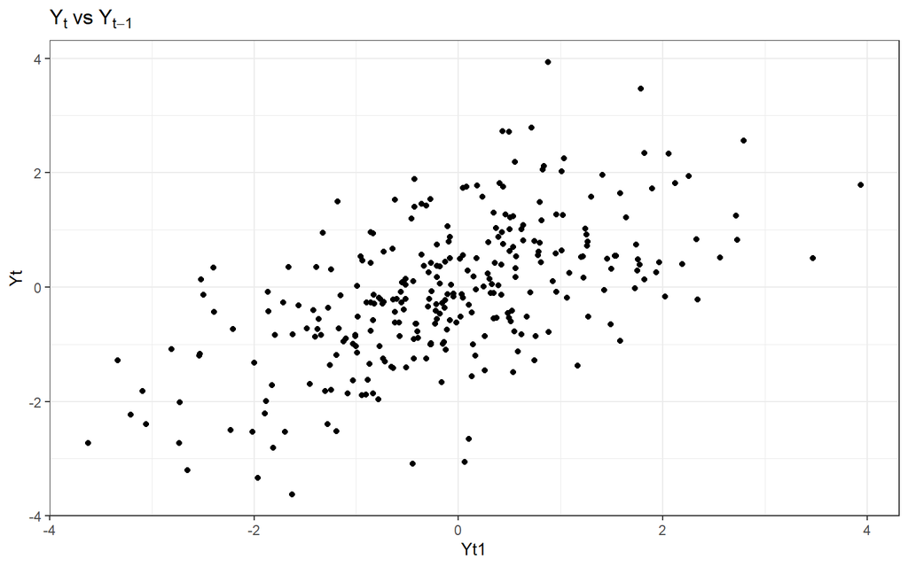

```r
Yv <- as.numeric(Y_manual)
Nn <- length(Yv)

df_lag <- data.frame(
  Yt  = Yv[4:Nn],
  Yt1 = Yv[3:(Nn - 1)],
  Yt2 = Yv[2:(Nn - 2)],
  Yt3 = Yv[1:(Nn - 3)]
)

ggplot(df_lag, aes(x = Yt1, y = Yt)) +
  geom_point() + theme_bw() + ggtitle(expression(Y[t]~"vs"~Y[t-1]))
```

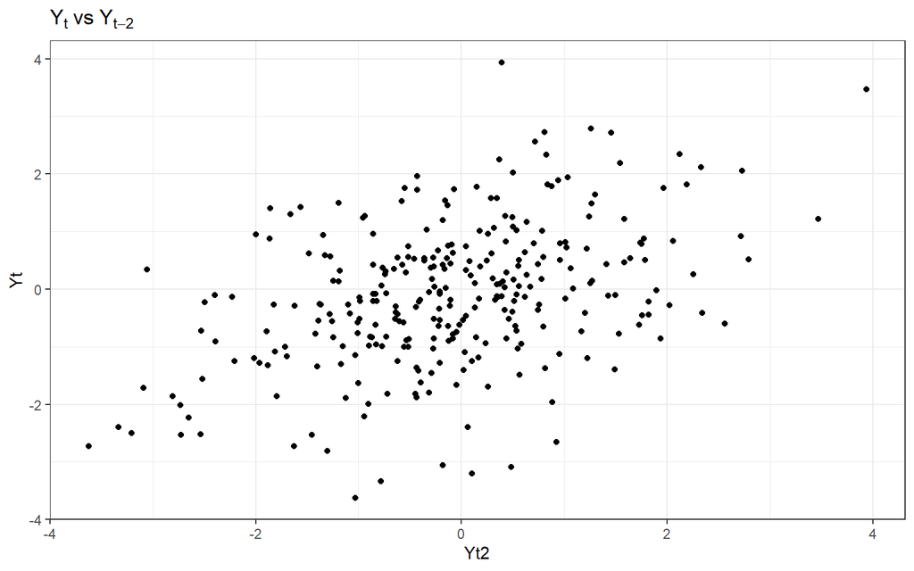

```r
ggplot(df_lag, aes(x = Yt2, y = Yt)) +
  geom_point() + theme_bw() + ggtitle(expression(Y[t]~"vs"~Y[t-2]))
```

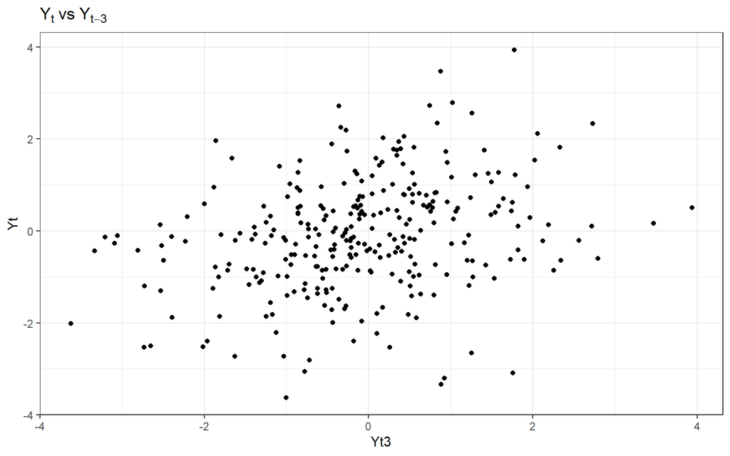

```r
ggplot(df_lag, aes(x = Yt3, y = Yt)) +
  geom_point() + theme_bw() + ggtitle(expression(Y[t]~"vs"~Y[t-3]))
```

Ketiga scatterplot menunjukkan pola **tren linear positif yang makin melemah** seiring bertambahnya lag ($Y_t$ vs $Y_{t-1}$ paling kuat,$Y_t$ vs $Y_{t-3}$ paling lemah namun tetap terlihat) — konsisten dengan ACF AR(2) yang meluruh perlahan, bukan terputus tegas seperti pada proses MA.

## Autokorelasi: Empiris vs Teoritis

```r
ac_manual <- acf(Y_manual, plot = FALSE)$acf[2:4]
ac_sim    <- acf(Y_sim, plot = FALSE)$acf[2:4]

hasil <- data.frame(
  Lag              = 1:3,
  Teoritis         = rho[1:3],
  Empiris_Manual   = ac_manual,
  Empiris_arimaSim = ac_sim
)
round(hasil, 3)
```

```
##      Lag Teoritis Empiris_Manual Empiris_arimaSim
## rho1   1    0.625          0.424            0.511
## rho2   2    0.512          0.288            0.364
## rho3   3    0.381          0.169            0.256
```

# Proses ARMA (2,2)

```r
phi1   <- 0.5;  phi2   <- 0.2
theta1 <- 0.4;  theta2 <- 0.6

c(syarat1 = phi1 + phi2 < 1,
  syarat2 = phi2 - phi1 < 1,
  syarat3 = abs(phi2) < 1)
```

```
## syarat1 syarat2 syarat3
##    TRUE    TRUE    TRUE
```

```r
rho_teori <- ARMAacf(ar = c(phi1, phi2), ma = c(theta1, theta2), lag.max = 6)
round(rho_teori, 4)
```

```
##      0      1      2      3      4      5      6
## 1.0000 0.8592 0.7492 0.5464 0.4231 0.3208 0.2450
```

## Membangkitkan Data

### Manual

```r
n <- 300
burn <- 50
e <- rnorm(n + burn)

Y <- numeric(n + burn)
for (t in 3:(n + burn)) {
  Y[t] <- phi1 * Y[t - 1] + phi2 * Y[t - 2] +
    e[t] + theta1 * e[t - 1] + theta2 * e[t - 2]
}
Y_manual <- ts(Y[(burn + 1):(n + burn)])

mean(Y_manual)
```

```
## [1] 0.03575814
```

```r
var(Y_manual)
```

```
## [1] 3.745712
```

### Arima.sim

```r
Y_sim <- arima.sim(n = 300,
                    model = list(ar = c(phi1, phi2), ma = c(theta1, theta2)))

mean(Y_sim)
```

```
## [1] -0.3673356
```

```r
var(Y_sim)
```

```
## [1] 4.94939
```

## Plot Time Series

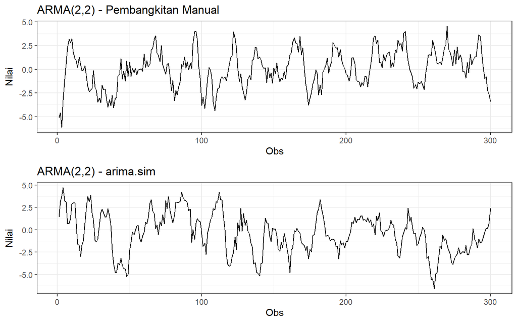

```r
plot_manual <- Y_manual |> as_tsibble() |>
  ggplot(aes(x = index, y = value)) + geom_line() + theme_bw() +
  xlab("Obs") + ylab("Nilai") + ggtitle("ARMA(2,2) - Pembangkitan Manual")

plot_sim <- Y_sim |> as_tsibble() |>
  ggplot(aes(x = index, y = value)) + geom_line() + theme_bw() +
  xlab("Obs") + ylab("Nilai") + ggtitle("ARMA(2,2) - arima.sim")

ggpubr::ggarrange(plot_manual, plot_sim, nrow = 2)
```

## Plot ACF, PACF, dan EACF

### Plot ACF

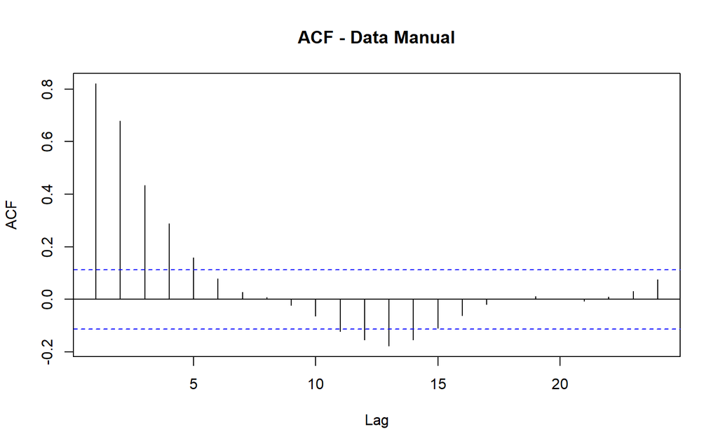

```r
acf(Y_manual, main = "ACF - Data Manual")
```

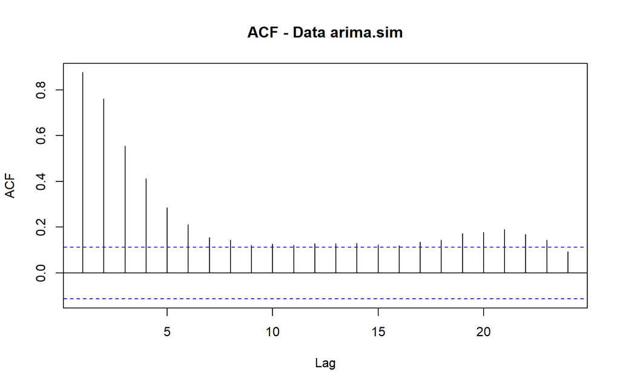

```r
acf(Y_sim, main = "ACF - Data arima.sim")
```

Plot ACF meluruh secara bertahap (*tails off*), sesuai perhitungan teoritis `ARMAacf()` — karena adanya komponen AR, ACF tidak terputus tegas seperti pada proses MA murni.

### Plot PACF

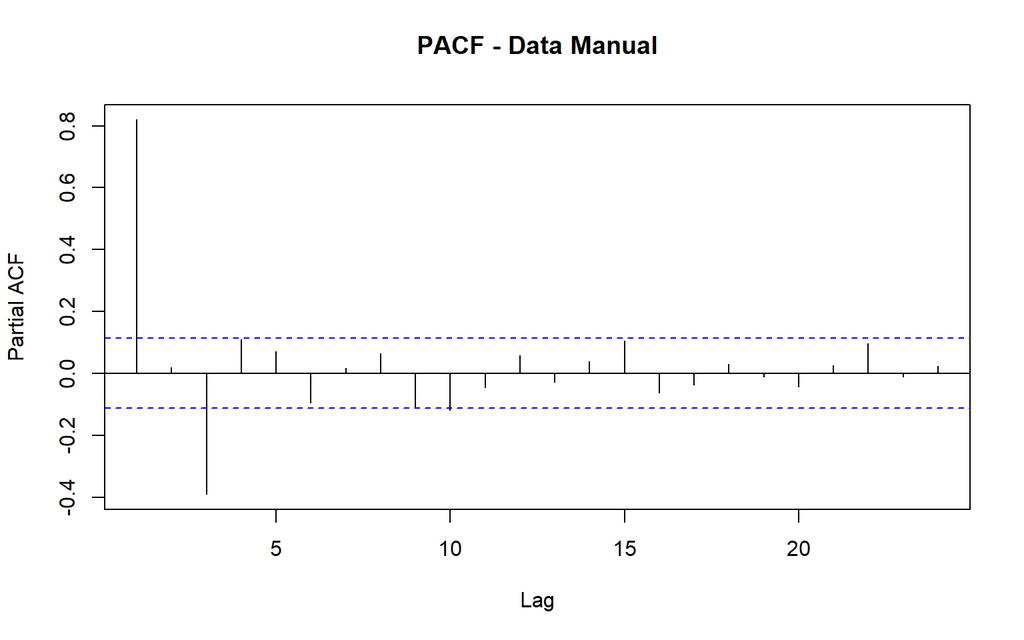

```r
pacf(Y_manual, main = "PACF - Data Manual")
```

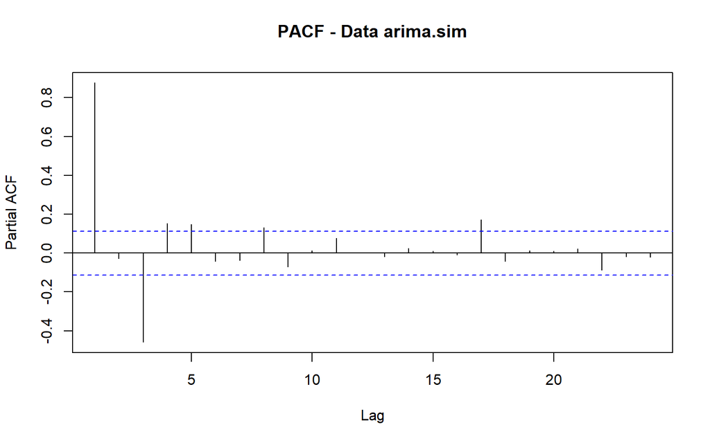

```r
pacf(Y_sim, main = "PACF - Data arima.sim")
```

### Plot EACF

```r
TSA::eacf(Y_manual)
```

```
## AR/MA
##   0 1 2 3 4 5 6 7 8 9 10 11 12 13
## 0 x x x x x o o o o o x  x  x  x
## 1 o x o x o o o o o o o  o  x  o
## 2 o x o x o o o o o o o  o  o  o
## 3 x x x o o o o o o o o  o  x  o
## 4 x x x o o o o o o o o  o  o  o
## 5 x x x o o o o o o o o  o  o  o
## 6 o x x o o x o o o o o  o  o  o
## 7 o o x x o x o o x o o  o  o  o
```

```r
TSA::eacf(Y_sim)
```

```
## AR/MA
##   0 1 2 3 4 5 6 7 8 9 10 11 12 13
## 0 x x x x x x x x x x x  x  x  x
## 1 o x o o o o x o o o o  o  o  o
## 2 o x x o o o x o o o o  o  o  o
## 3 x x x o o o o o o o o  o  o  o
## 4 x x o o x o o o o o o  o  o  o
## 5 x x o x x x o o o o o  o  o  o
## 6 x x x x o o o o o o o  o  o  o
## 7 x x x x o o o x o o o  o  o  o
```

Pada proses campuran, pola segitiga nilai tidak signifikan pada tabel EACF diperkirakan memiliki titik sudut (*vertex*) di sekitar **baris AR = 2, kolom MA = 2**, sesuai orde ARMA(2,2) yang dibangkitkan (meski pada data riil posisi vertex bisa sedikit bergeser akibat variasi sampel).

### Identifikasi Stasioneritas

```r
tseries::adf.test(Y_manual)
```

```
##
##  Augmented Dickey-Fuller Test
##
## data:  Y_manual
## Dickey-Fuller = -5.4322, Lag order = 6, p-value = 0.01
## alternative hypothesis: stationary
```

```r
tseries::adf.test(Y_sim)
```

```
##
##  Augmented Dickey-Fuller Test
##
## data:  Y_sim
## Dickey-Fuller = -4.7905, Lag order = 6, p-value = 0.01
## alternative hypothesis: stationary
```

$H_0$: Data tidak stasioner dalam rataan $H_1$: Data stasioner dalam rataan

## Scatterplot $Y_t$ dengan Lag

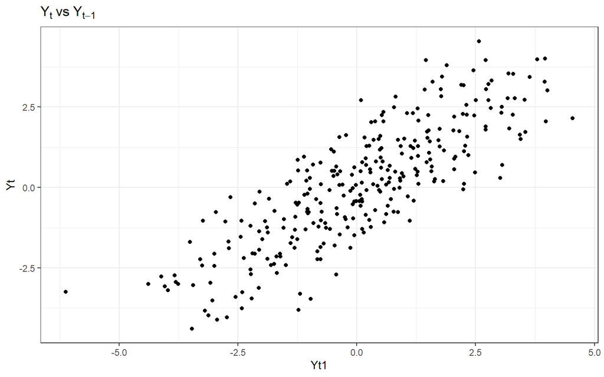

```r
Yv <- as.numeric(Y_manual)
Nn <- length(Yv)

df_lag <- data.frame(
  Yt  = Yv[4:Nn],
  Yt1 = Yv[3:(Nn - 1)],
  Yt2 = Yv[2:(Nn - 2)],
  Yt3 = Yv[1:(Nn - 3)]
)

ggplot(df_lag, aes(x = Yt1, y = Yt)) +
  geom_point() + theme_bw() + ggtitle(expression(Y[t]~"vs"~Y[t-1]))
```

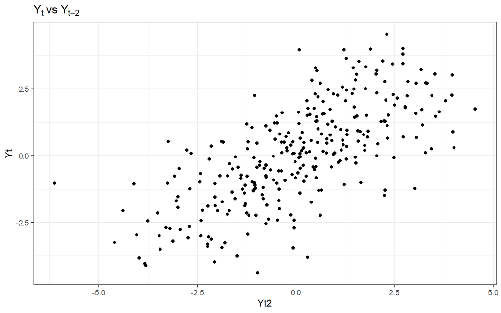

```r
ggplot(df_lag, aes(x = Yt2, y = Yt)) +
  geom_point() + theme_bw() + ggtitle(expression(Y[t]~"vs"~Y[t-2]))
```

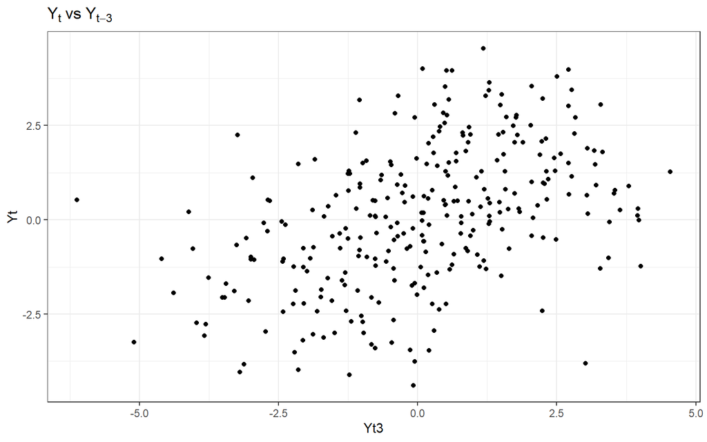

```r
ggplot(df_lag, aes(x = Yt3, y = Yt)) +
  geom_point() + theme_bw() + ggtitle(expression(Y[t]~"vs"~Y[t-3]))
```

Ketiga scatterplot menunjukkan pola **tren linear positif yang cukup kuat**, bahkan pada $Y_t$ vs $Y_{t-3}$ masih terlihat pola yang jelas (tidak seacak pada kasus MA(2)) — konsisten dengan ACF ARMA(2,2) yang meluruh perlahan akibat komponen AR di dalamnya.

## Autokorelasi: Empiris vs Teoritis

```r
ac_manual <- acf(Y_manual, plot = FALSE)$acf[2:4]
ac_sim    <- acf(Y_sim, plot = FALSE)$acf[2:4]

hasil <- data.frame(
  Lag              = 1:3,
  Teoritis         = rho_teori[2:4],
  Empiris_Manual   = ac_manual,
  Empiris_arimaSim = ac_sim
)
round(hasil, 3)
```

```
##   Lag Teoritis Empiris_Manual Empiris_arimaSim
## 1   1    0.859          0.679            0.761
## 2   2    0.749          0.434            0.555
## 3   3    0.546          0.289            0.412
```